# Binomial regression in R

July 10, 2019

# 1 Logistic (Binomial) regression

Let’s start with a very simple example, where we have two groups (goverened by $x$), each with a different probability of success. Let the probability of success equal $p=(1-x)p_0 + xp_1$, so that

- If $x=0$, then $p=0.4$
- If $x=1$, then $p=0.6$

We’ll sample 50 draws from a binomial distribution, each with $n=10$. In terms of DNA methylation at a particular loci, this would be 50 samples (25 in each group), each with coverage 10, where there’s a 20% methylation difference between the two groups.

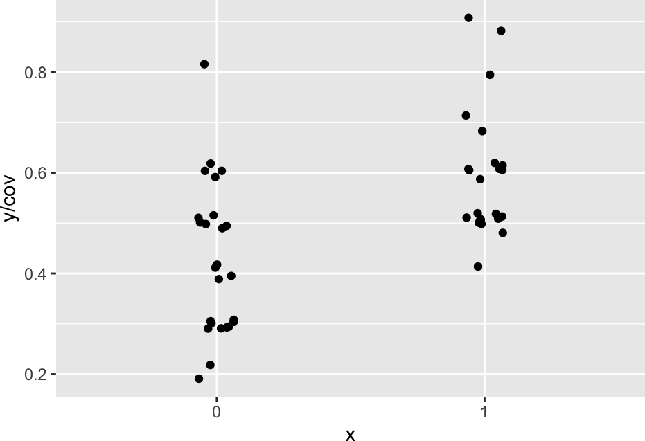

```r
library(ggplot2)
library(dplyr)

set.seed(1)
n <- 50
cov <- 10
x <- c(rep(0,n/2), rep(1, n/2))
p <- 0.4 + 0.2*x
y <- rbinom(n, cov, p)

ggplot(data.frame(x=factor(x),y=as.numeric(y)),
            aes(x=x, y=y/cov)) +
  geom_point(position=position_jitter(height=0.02, width=0.07)) +
  xlab("x") +
  ylab("y/cov")
```

Now we fit a logistic regression model with $x$ as a covariate, using the logit link
$$log(\frac{p}{1-p})$$

```r
# Fit a logistic regression model
model0 <- glm(cbind(y, cov-y) ~ x, family="binomial")
summary(model0)
```

```
##
## Call:
## glm(formula = cbind(y, cov - y) ~ x, family = "binomial")
##
## Deviance Residuals:
##      Min        1Q    Median        3Q       Max
## -1.50013  -0.58688  -0.05123   0.48348   2.43452
##
## Coefficients:
##             Estimate Std. Error z value Pr(>|z|)
## (Intercept)  -0.3064     0.1280  -2.394 0.016668 *
## x             0.6786     0.1815   3.739 0.000185 ***
## ---
## Signif. codes:  0 '***' 0.001 '**' 0.01 '*' 0.05 '.' 0.1 ' ' 1
##
## (Dispersion parameter for binomial family taken to be 1)
##
##     Null deviance: 53.720  on 49  degrees of freedom
## Residual deviance: 39.537  on 48  degrees of freedom
## AIC: 177.99
##
## Number of Fisher Scoring iterations: 4
```

We see that $x$ is very predictive of $y$, as we expect.

## 1.1 Exercise

Recall that the estimated probability of success for the logistic regression model is the inverse logit function
$$\frac{e^{\beta_0 + x\beta_1}}{1 + e^{\beta_0 + x\beta_1}}.$$
For `model0`, find the estimated probability of success when $x=0$ and when $x=1$.

```r
# when x = 0
exp(coef(model0)[1]) /  (1+exp(coef(model0)[1]))
```

```
## (Intercept)
##       0.424
```

```r
# when x = 1
exp(sum(coef(model0))) /  (1+exp(sum(coef(model0))))
```

```
## [1] 0.592
```

Try fitting an ordinary least squares (linear regression) model with `lm` on transformed proportions. Recall that this model assumes normally distributed error and does not explicitly model the count nature of the data. How does this model compare to the logistic model?

```r
logit <- function(p){
  log(p/(1-p))
}
linearfit <- lm(logit(y/cov) ~ x)

summary(linearfit)
```

```
##
## Call:
## lm(formula = logit(y/cov) ~ x)
##
## Residuals:
##      Min       1Q   Median       3Q      Max
## -1.05971 -0.42876 -0.05109  0.32659  1.76846
##
## Coefficients:
##             Estimate Std. Error t value Pr(>|t|)
## (Intercept)  -0.3266     0.1298  -2.516 0.015268 *
## x             0.7553     0.1836   4.115 0.000151 ***
## ---
## Signif. codes:  0 '***' 0.001 '**' 0.01 '*' 0.05 '.' 0.1 ' ' 1
##
## Residual standard error: 0.649 on 48 degrees of freedom
## Multiple R-squared:  0.2608, Adjusted R-squared:  0.2454
## F-statistic: 16.93 on 1 and 48 DF,  p-value: 0.0001513
```

Examine the distrition of the residuals of the previous model. Do they appear normal?

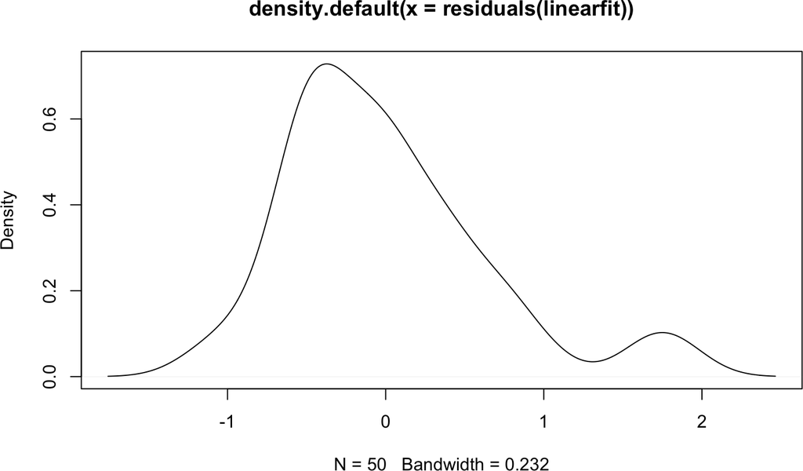

```r
plot(density(residuals(linearfit)))
```

# 2 Logistic regression with overdispersion

The previous example did not allow for any biological variability (only sampling variability). More realistically, we’ll sample each sample’s methylation probability as a random quantity, where the distributions between groups have a different mean.

To do so, we’ll use the beta distribution, since it is a natural fit for modeling proportions. Here, we let the probabilities used by the binomial sampling be equal to the probabilities:
$$p=(1-x)p_0 + xp_1,$$
where:
$$p_i \sim Beta(\alpha_i,\beta_i).$$
We set the hyperparameters as follows:

- when $x=0$: $\alpha_0=4$ and $\beta_0=6$
- when $x=1$: $\alpha_1=6$ and $\beta_1=4$

Since the mean of the beta distribution is
$$E(p_i) = \frac{\alpha_i}{\alpha_i+\beta_i},$$
the average probability of success for the first group ($x=0$) is 0.4, and the average probability of success for the second group ($x=1$) is 0.6. This is because
$$E[p] = (1-x)E[p_0] + xE[p_1].$$

Then, we plot the outcomes $y$ against the known value $x$.

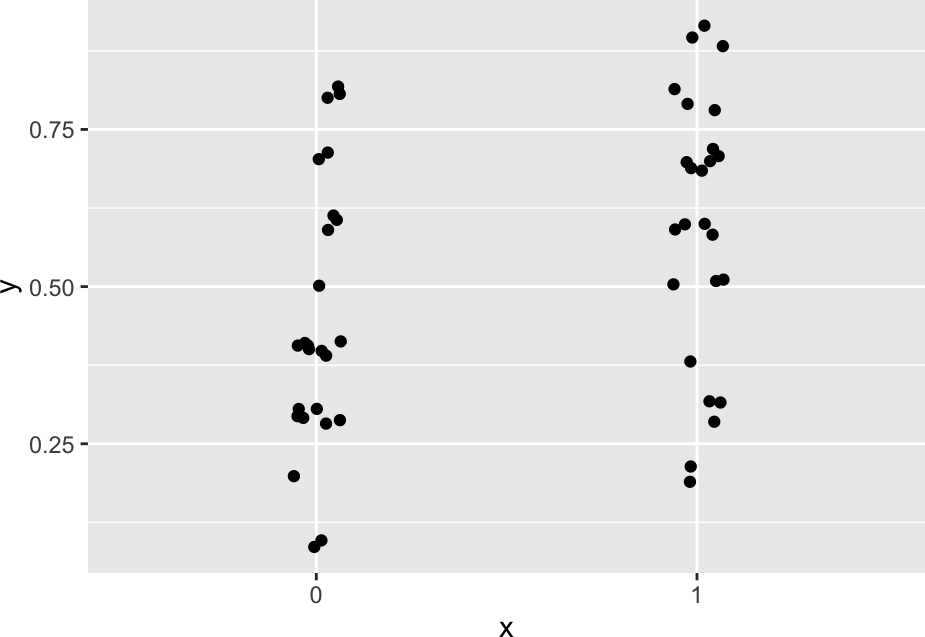

```r
set.seed(1)
n <- 50
cov <- 10
x <- c(rep(0,n/2), rep(1, n/2))
p <- pmin((1-x)*rbeta(n,4,6) + x*rbeta(n,6,4), 1)
y <- rbinom(n, cov, p)

ggplot(data.frame(x=factor(x),y=as.numeric(y), p),
            aes(x=x, y=y/cov)) +
  geom_point(position=position_jitter(height=0.02, width=0.07)) +
  xlab("x") +
  ylab("y")
```

Now we fit a logistic regression model with $x$ as a covariate. Note that the additional beta noise is not modeled.

```r
# Fit a logistic regression model
model1 <- glm(cbind(y, cov-y) ~ x, family="binomial")
summary(model1)
```

```
##
## Call:
## glm(formula = cbind(y, cov - y) ~ x, family = "binomial")
##
## Deviance Residuals:
##     Min       1Q   Median       3Q      Max
## -2.5619  -0.9339  -0.1277   0.9894   2.3089
##
## Coefficients:
##             Estimate Std. Error z value Pr(>|z|)
## (Intercept)  -0.2249     0.1273  -1.767 0.077203 .
## x             0.6138     0.1812   3.388 0.000704 ***
## ---
## Signif. codes:  0 '***' 0.001 '**' 0.01 '*' 0.05 '.' 0.1 ' ' 1
##
## (Dispersion parameter for binomial family taken to be 1)
##
##     Null deviance: 104.717  on 49  degrees of freedom
## Residual deviance:  93.101  on 48  degrees of freedom
## AIC: 225.76
##
## Number of Fisher Scoring iterations: 3
```

Now we see that $x$ is still predictive of $y$, however the coefficient has a slightly larger *p*-value, likely influenced by the extra beta noise in the binomial probabilities.

## 2.1 Exercise

For `model1`, find the estimated probability of success when $x=0$ and when $x=1$.

```r
# when x = 0
exp(coef(model1)[1]) /  (1+exp(coef(model1)[1]))
```

```
## (Intercept)
##       0.444
```

```r
# when x = 1
exp(sum(coef(model1))) /  (1+exp(sum(coef(model1))))
```

```
## [1] 0.596
```

## 2.2 Bootstrap comparison

This result is just based on one random sample - to convince ourselves that this is a consistent effect, we could repeat these two model fits on many random samples (e.g. using the [dplyr](https://cran.r-project.org/web/packages/dplyr/index.html), [broom](https://cran.r-project.org/web/packages/broom/index.html), and [purrr](https://cran.r-project.org/web/packages/purrr/index.html) packages). Here we show results for 1,000 replicates.

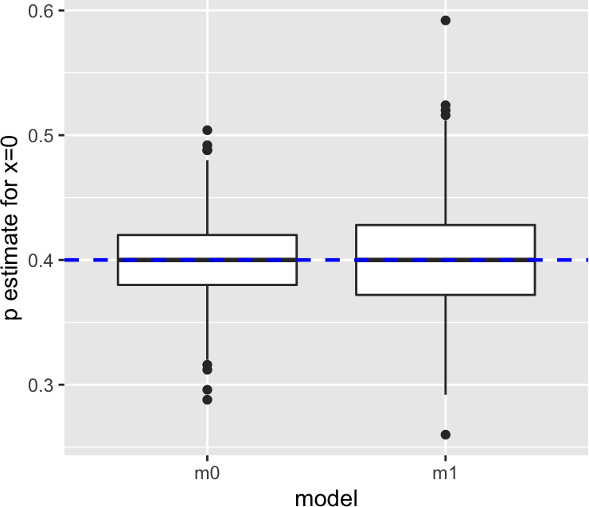

```r
library(dplyr)
library(broom)
library(purrr)

set.seed(10)

n <- 50
cov <- 10
B <- 1000
x <- c(rep(0,n/2), rep(1, n/2))

# functions to run one replicate for each model
m0_rep <- function(){
  data.frame(x = c(rep(0,n/2), rep(1, n/2))) %>%
    mutate(p = 0.4 + 0.2*x,
           cov = cov) %>%
    mutate(y=rbinom(n, cov, p)) %>%
    do(tidy(glm(cbind(y, cov-y) ~ x, family="binomial", data=.),
            conf.int = TRUE))
}

m1_rep <- function(){
  data.frame(x = c(rep(0,n/2), rep(1, n/2))) %>%
    mutate(p = pmin((1-x)*rbeta(n,4,6) + x*rbeta(n,6,4), 1),
           cov = cov) %>%
    mutate(y=rbinom(n, cov, p)) %>%
    do(tidy(glm(cbind(y, cov-y) ~ x, family="binomial", data=.),
            conf.int = TRUE))
}

# replicate B times
m0_all <- replicate(B, m0_rep(), simplify=FALSE) %>%
  do.call("rbind", .) %>%
  mutate(model="m0") %>%
  mutate(n = sort(rep(1:B, 2)))
m1_all <- replicate(B, m1_rep(), simplify=FALSE) %>%
  do.call("rbind", .) %>%
  mutate(model="m1") %>%
  mutate(n = sort(rep(1:B, 2)))

# combine and pull out relevant info
all <- rbind(m0_all, m1_all)
x <- filter(all, term == "x")
prob1 <- all %>% group_by(model,n) %>%
  summarize(p = sum(estimate))
prob0 <- all %>% filter(term == "(Intercept)") %>%
  mutate(p = estimate)

prob0 %>% ggplot(aes(x = model, y = exp(p) / (1+exp(p)))) +
  geom_boxplot() +
  ylab("p estimate for x=0") +
  geom_hline(yintercept=0.4, linetype="dashed", size=0.8, color = "blue")
```

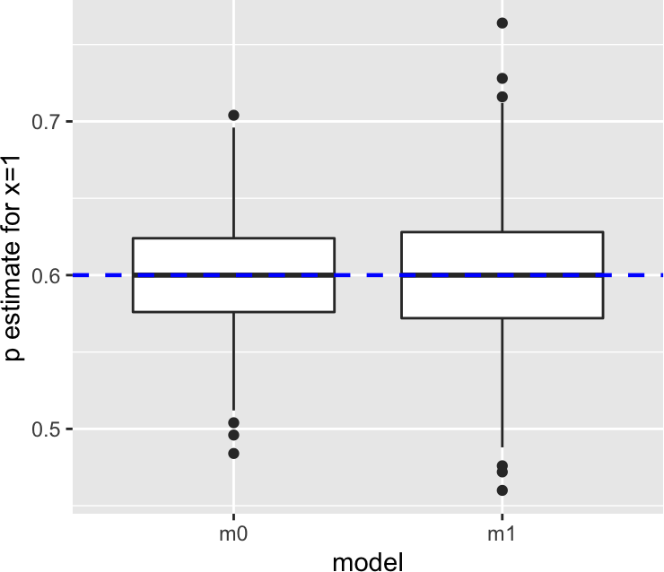

```r
prob1 %>% ggplot(aes(x = model, y = exp(p) / (1+exp(p)))) +
  geom_boxplot() +
  ylab("p estimate for x=1") +
  geom_hline(yintercept=0.6, linetype="dashed", size=0.8, color = "blue")
```

```r
sum(all$p.value[all$model=="m0"] > 0.05)
```

```
## [1] 107
```

```r
sum(all$p.value[all$model=="m1"] > 0.05)
```

```
## [1] 199
```

# 3 Beta-binomial regression

In order to account for the overdispersion in the binomial probabilities, let’s try fitting a beta-binomial regression model to the data instead.

```r
library(aod)
dat <- data.frame(s = y, f = cov-y, x = factor(c(rep(0,n/2), rep(1, n/2))))
model2 <- betabin(cbind(s,f) ~ x, ~ x, data=dat)
summary(model2)
```

```
## Beta-binomial model
## -------------------
## betabin(formula = cbind(s, f) ~ x, random = ~x, data = dat)
##
## Convergence was obtained after 95 iterations.
##
## Fixed-effect coefficients:
##               Estimate Std. Error    z value Pr(> |z|)
## (Intercept) -2.230e-01  1.627e-01 -1.371e+00 1.705e-01
## x1           6.086e-01  2.373e-01  2.565e+00 1.032e-02
##
## Overdispersion coefficients:
##         Estimate Std. Error   z value   Pr(> z)
## phi.x0 7.055e-02  4.421e-02 1.596e+00 5.526e-02
## phi.x1 8.874e-02  4.716e-02 1.882e+00 2.995e-02
##
## Log-likelihood statistics
##    Log-lik      nbpar    df res.   Deviance        AIC       AICc
## -1.055e+02          4         46  8.225e+01  2.189e+02  2.198e+02
```

Notice that the estimated coefficients are similar to `model1`. Also notice that the standard errors are larger, and therefore the *p*-value for the $x$ covariate is larger. We can also see that new overdispersion parameters ($\phi_{x=0}, \phi_{x=1}$) are estimated. Recall that in the beta-binomial regression model,
$$\phi_i = \frac{1}{\alpha_i+\beta_i+1}$$

## 3.1 Exercise

For `model2`, find the estimated probability of success when $x=0$ and when $x=1$.

```r
# when x = 0
exp(coef(model2)[1]) /  (1+exp(coef(model2)[1]))
```

```
## (Intercept)
##   0.4444839
```

```r
# when x = 1
exp(sum(coef(model2))) /  (1+exp(sum(coef(model2)[2])))
```

```
## [1] 0.5181786
```

What are the true values of the overdispersion parameters in this model? How close are the estimated overdispersion coefficients in `model2`?

```r
# phi1 = 1/ (alpha1 + beta1 + 1)
phi1 <- 1/(4 + 6 + 1)
phi1
```

```
## [1] 0.09090909
```

```r
# phi2 is the same as phi1 since the sum of alpha + beta are equal

summary(model2)@Phi$Estimate - phi1
```

```
## [1] -0.020356922 -0.002169733
```

## 3.2 Bootstrap comparison

We’ll explore how the beta-binomial regression model differs from logistic regression on the same dataset. Here, we’ll use a null comparison, where the $x$ variable actually does not have any influence on the binomial probabilities. In terms of methylation, this would be a case where there’s no differential methylation. Ideally, the model will estimate the effect of $x$ ($\beta_1$) close to zero.

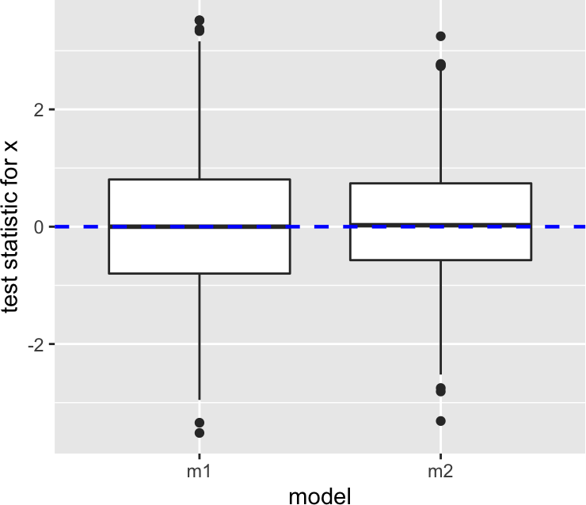

```r
set.seed(4)

n <- 20
cov <- 5
B <- 1000
x <- c(rep(0,n/2), rep(1, n/2))

# functions to run one replicate for each model
data_rep <- function(){
  data.frame(x = c(rep(0,n/2), rep(1, n/2))) %>%
    mutate(p = rbeta(n,4,4),
           cov = cov) %>%
    mutate(y=rbinom(n, cov, p)) %>%
    mutate(f=cov-y) %>%
    mutate(x = as.factor(x))
}

dat <- replicate(B, data_rep(), simplify=FALSE)

m1_all <- lapply(dat, function(l)
  tidy(glm(cbind(y, cov-y) ~ x, family="binomial", data=l),
            conf.int = TRUE)) %>%
  do.call("rbind", .) %>%
  mutate(model="m1") %>%
  mutate(n = sort(rep(1:B, 2))) %>%
  select(estimate, p.value, n, term, model, std.error)

m2_all <- lapply(dat, function(l)
  summary(betabin(cbind(y,f) ~ x, ~ x, data=l))@Coef) %>%
  do.call("rbind", .) %>%
  mutate(model="m2") %>%
  mutate(n = sort(rep(1:B, 2))) %>%
  mutate(term = rep(c("int", "x1"), B)) %>%
  mutate(estimate=Estimate,
         p.value = `Pr(> |z|)`,
         std.error = `Std. Error`) %>%
  select(estimate, p.value, n, term, model, std.error)

# combine and pull out relevant info
all <- rbind(m1_all, m2_all)
x <- filter(all, term == "x")
prob1 <- all %>% group_by(model,n) %>%
  summarize(p = sum(estimate))
prob0 <- all %>% filter(term != "x1") %>%
  mutate(p = estimate/std.error)
prob1 <- all %>% filter(term == "x1") %>%
  mutate(p = estimate/std.error)

prob1 %>% ggplot(aes(x = model, y = p)) +
  geom_boxplot() +
  ylab("test statistic for x") +
  geom_hline(yintercept=0, linetype="dashed", size=0.8, color = "blue")
```

```r
sum(all$p.value[all$model=="m1"] < 0.1, na.rm = TRUE)
```

```
## [1] 339
```

```r
sum(all$p.value[all$model=="m2"] < 0.1, na.rm = TRUE)
```

```
## [1] 195
```

We see that the beta-binomial regression model performs better. This is seen in the test statistic estimates for the $x$ coefficient that are more tightly centered on zero, and the fewer number of rejections at the 0.1 level for a significant coefficient for $x$.

# 4 Pitfalls of GLM

Let’s to fit a model to some data which is perfectly separated (e.g. all successes are in one group and all failures in another, with group as the predictor).

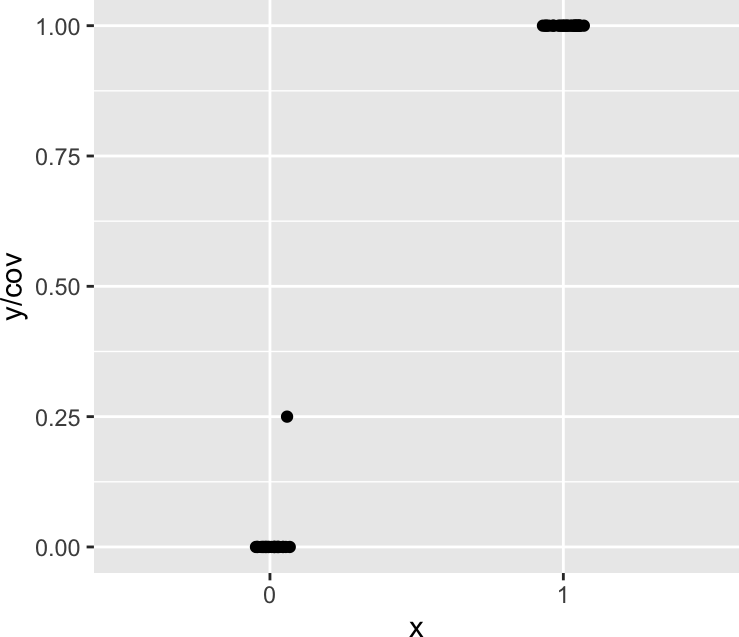

```r
set.seed(1)
n <- 50
cov <- 4
x <- c(rep(0,n/2), rep(1, n/2))
p <- 0.01 + 0.99*x
y <- rbinom(n, cov, p)

ggplot(data.frame(x=factor(x),y=as.numeric(y)),
            aes(x=x, y=y/cov)) +
  geom_point(position=position_jitter(height=0, width=0.07)) +
  xlab("x") +
  ylab("y/cov")
```

```r
# Fit a logistic regression model
model.sep <- glm(cbind(y, cov-y) ~ x, family="binomial")
summary(model.sep)
```

```
##
## Call:
## glm(formula = cbind(y, cov - y) ~ x, family = "binomial")
##
## Deviance Residuals:
##      Min        1Q    Median        3Q       Max
## -0.28355  -0.28355   0.00004   0.00004   2.18448
##
## Coefficients:
##             Estimate Std. Error z value Pr(>|z|)
## (Intercept)   -4.595      1.005  -4.572 4.83e-06 ***
## x             26.960   4359.342   0.006    0.995
## ---
## Signif. codes:  0 '***' 0.001 '**' 0.01 '*' 0.05 '.' 0.1 ' ' 1
##
## (Dispersion parameter for binomial family taken to be 1)
##
##     Null deviance: 272.7402  on 49  degrees of freedom
## Residual deviance:   6.7016  on 48  degrees of freedom
## AIC: 12.428
##
## Number of Fisher Scoring iterations: 20
```

Notice how the estimate of the coefficient for $x$ and its standard error are extremely large, which yields a $p$-value close to 1. This is because the true proportion difference attributable to $x$ is close to 1. This means that the
$$\frac{e^\beta}{1+e^\beta } \approx 1$$
This is a problem, because it means that the solution for $\beta$ approaches $\infty$, and the MLE does not exist.

## 4.1 Alternative link function

This instability is avoided by using an alternative link function, such as the arcsine link
$$arcsin(2p-1).$$
Setting the inverse link function to 1 and solving gives
$$\frac{sin(\beta) + 1}{2} = 1$$
which yields $\beta = \pi/2$.

This link function is similar to the logit in that it transforms a (0,1) quantity in order to stabilize variance, but the transformation is less drastic in the extremes.

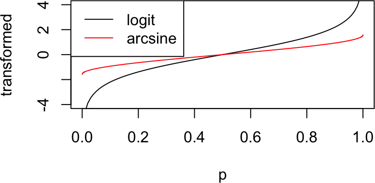

```r
p <- sort(c(seq(0,0.01, by=1e-5), seq(0,1,by=0.01), seq(0.99,1, by=1e-5)))
plot(p, log(p/(1-p)), type = "l", ylab = "transformed", ylim=c(-4,4))
lines(p, asin(2*p-1), col="red")
legend("topleft", legend=c("logit", "arcsine"), col=c("black", "red"),
       lty =c(1,1))
```